# Market Basket Analysis for Electrodinex

Pilar Canals & David Gibert

October 31, 2018

# **Introduction**

The objective of this report is to find reasons among relations between order transactions to justify the decision on purchasing Electronidex company. The transactional data belongs to 1 month period of Electronidex’s sells.

# **Summary**

After doing the analysis we advice that it would be interesting to purchase the company in order to add products like Desktops and Laptops to the portfolio.

We could expect to gain new customers from the Electronidex aquired products aswell.

*Even so, it would be important to keep in mind that the time period of sales of Electronidex’s transactions covers only one month, which means that it could be different from another one. This is because it would not be the same selling products on June than on December. It would be interesting then to have the sales data for the same period of time for both companies, as well as the transactional data of Blackwell.*

# **Conclusions by product**

Let’s look at some histograms that show the frequency of purchases for each category for both, Electrodinex and Blackwell.

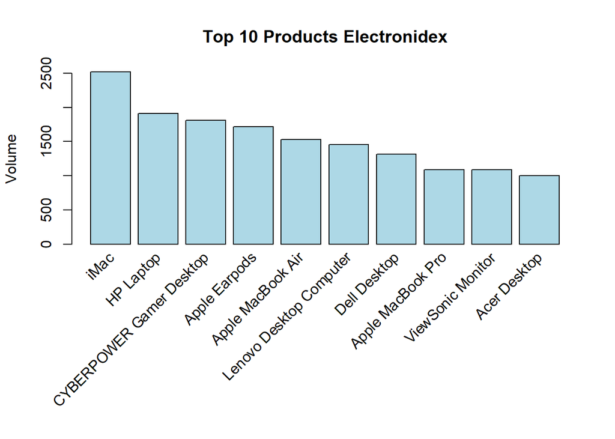

As we can see, Electronidex sells many different products. Products belong to brands like Apple or HP and to categories like Desktops or Monitors. Studying the products using those conditions could bring more insights aswell.

**In the following histograms, we can observe the different categories of products for each company.**

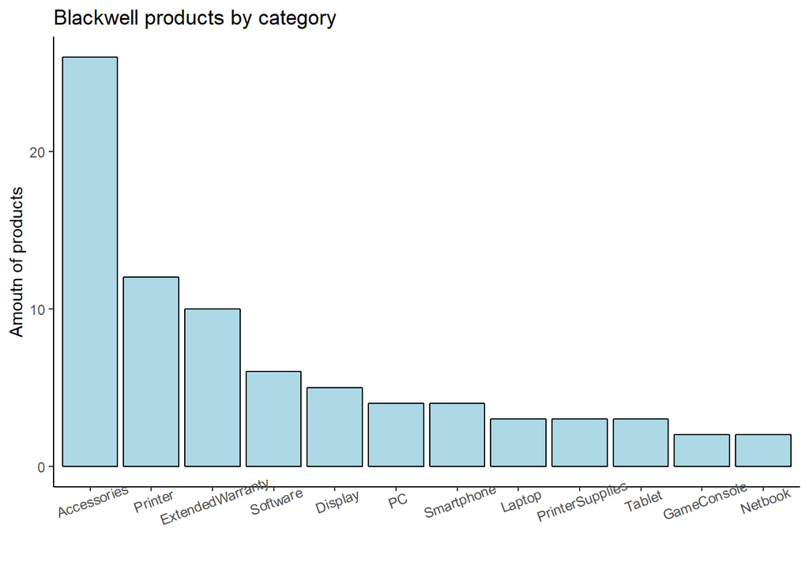

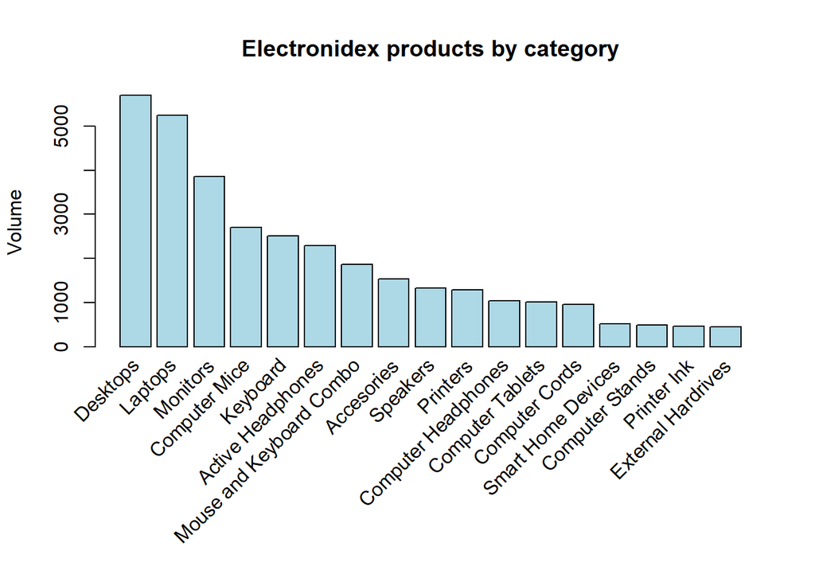

If we had the transactional data of both companies, we could confirm, as we observe in the histograms, that we should acquire Desktops and Laptops to increase the Blackwell catalog. This way, it would increase the volume of clients and company profit, since we know that Desktops and Laptops are the ones that have the greatest profitability at Blackwell.

# **Analysing relations among products**

```
##     lhs                                         rhs         support
## [1] {Acer Aspire,ViewSonic Monitor}          => {HP Laptop} 0.01077783
## [2] {ASUS 2 Monitor,Lenovo Desktop Computer} => {iMac}      0.01087951
## [3] {Apple Magic Keyboard,Dell Desktop}      => {iMac}      0.01016777
## [4] {ASUS Monitor,HP Laptop}                 => {iMac}      0.01179461
## [5] {ASUS 2 Monitor,HP Laptop}               => {iMac}      0.01108287
## [6] {Dell Desktop,ViewSonic Monitor}         => {HP Laptop} 0.01525165
##     confidence lift     count
## [1] 0.6022727  3.102856 106
## [2] 0.5911602  2.308083 107
## [3] 0.5847953  2.283232 100
## [4] 0.5829146  2.275889 116
## [5] 0.5828877  2.275784 109
## [6] 0.5747126  2.960869 150
```

The relationships among products is very low when the entire portfolio is analyzed globally. Apparently, this indicates that the products are not related to each other. In addition, the fact that in the same transaction there are products of the same category, for example Desktop, could indicate that the type of customer is Whole Sale apart from Retail.

In the following histogram we could guess that there are the two types of clients mentioned above. We reached that conclusion because the number of products per transaction varies between 1 and 30, so that transactions with a smaller number of products could be from the retail sector.

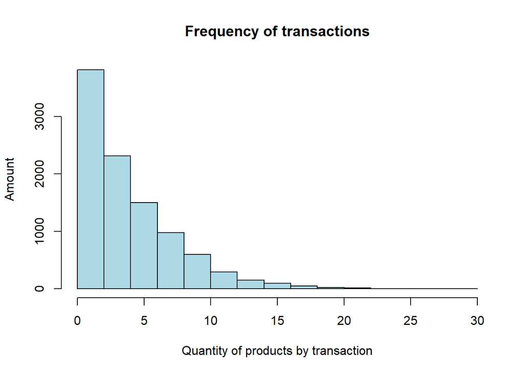

As we have seen, that iMac and HP Laptop are the best selling products, we will study the direct relationships with the other products.

```
##     lhs                 rhs                        support    confidence
## [1] {HP Laptop,iMac} => {ViewSonic Monitor}        0.02369090 0.3135935
## [2] {HP Laptop,iMac} => {Lenovo Desktop Computer}  0.02308083 0.3055182
## [3] {HP Laptop,iMac} => {Dell Desktop}             0.02226741 0.2947510
## [4] {HP Laptop}      => {ViewSonic Monitor}        0.04799187 0.2472499
## [5] {HP Laptop,iMac} => {CYBERPOWER Gamer Desktop} 0.01799695 0.2382234
##     lift     count
## [1] 2.842574 233
## [2] 2.063716 227
## [3] 2.199451 219
## [4] 2.241200 472
## [5] 1.295151 177
```

We can conclude that the products with more sales, “iMac” and “HP Laptop”, are not related to the rest of products due to the low values on support and confidence.

# **Conclusions by brand**

We have identified the brands with more products and the rest has been grouped with the name “Others”.

```
##     lhs                              rhs      support    confidence
## [1] {Acer,Asus,HP,Logitech}       => {Others} 0.01281139 1.0000000
## [2] {Acer,Apple,Asus,HP,Logitech} => {Others} 0.01128622 1.0000000
## [3] {Acer,HP,Lenovo,Logitech}     => {Others} 0.01016777 0.9900990
## [4] {Dell,HP,Lenovo,Logitech}     => {Others} 0.01067616 0.9813084
## [5] {Acer,Apple,Asus,Dell,HP}     => {Others} 0.01586172 0.9811321
## [6] {Acer,Asus,Dell,HP}           => {Others} 0.01789527 0.9777778
##     lift     count
## [1] 1.584501 126
## [2] 1.584501 111
## [3] 1.568813 100
## [4] 1.554885 105
## [5] 1.554605 156
## [6] 1.549290 176
```

As we can see, the strongest rule among categories is directly related with the category “Others”, composed mainly by accessories.

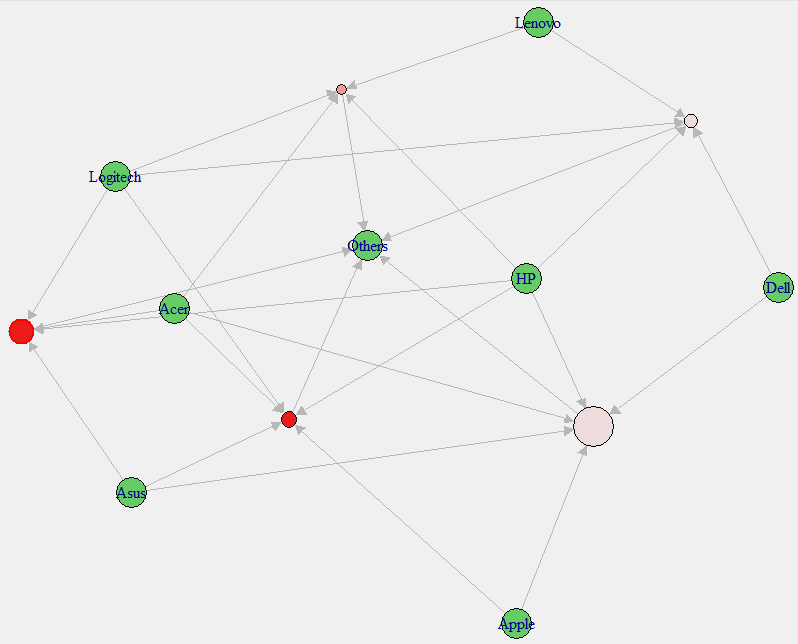

# **Insights about Apple**

```
##     lhs        rhs      support   confidence lift     count
## [1] {Apple} => {Others} 0.4061007 0.6373065  1.009813 3994
## [2] {Apple} => {HP}     0.2201322 0.3454603  1.067757 2165
```

# **Conclusions by category**

```
##     lhs                           rhs           support confidence     lift count
## [1] {Computer Mice,
##      Desktops,
##      Monitors,
##      Mouse and Keyboard Combo,
##      Printers}                 => {Laptops}  0.01077783  0.9298246 1.739883   106
## [2] {Active Headphones,
##      Computer Mice,
##      Computer Tablets,
##      Monitors}                 => {Desktops} 0.01016777  0.9259259 1.596508   100
## [3] {Computer Mice,
##      Laptops,
##      Monitors,
##      Mouse and Keyboard Combo,
##      Printers}                 => {Desktops} 0.01077783  0.9217391 1.589289   106
## [4] {Computer Mice,
##      Computer Tablets,
##      Keyboard,
##      Monitors}                 => {Desktops} 0.01159126  0.9193548 1.585178   114
## [5] {Accesories,
##      Computer Headphones,
##      Laptops,
##      Monitors}                 => {Desktops} 0.01250635  0.9179104 1.582687   123
## [6] {External Hardrives,
##      Laptops,
##      Monitors}                 => {Desktops} 0.01199797  0.9147287 1.577201   118
```

As we can see, the strongest rules are related with Desktop and Laptops products.

# **Relations with the strongest product categories**

```
##     lhs                   rhs             support   confidence lift
## [1] {Desktops,Laptops} => {Monitors}      0.1825114 0.5689382  1.447363
## [2] {Desktops}         => {Monitors}      0.2785968 0.4803647  1.222035
## [3] {Laptops}          => {Monitors}      0.2404677 0.4499619  1.144691
## [4] {Desktops,Laptops} => {Computer Mice} 0.1224199 0.3816165  1.390588
## [5] {Desktops,Laptops} => {Keyboard}      0.1146924 0.3575277  1.399238
## [6] {Desktops}         => {Computer Mice} 0.1879004 0.3239832  1.180576
##     count
## [1] 1795
## [2] 2740
## [3] 2365
## [4] 1204
## [5] 1128
## [6] 1848
```

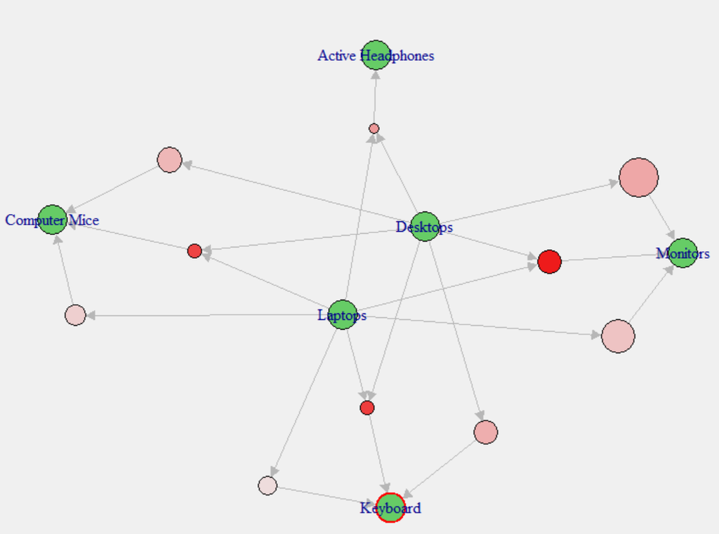

We can see that Electronidex sells many accessories when it sells different Desktops or Laptops, which led us to think that this is very interesting for Blackwell in case of buying Electronidex. It can increase the sales of its own accessories as well as attract the customers of the new acquired products.

# **Suggestions**

- Detailed analysis with transactional data from both companies for the same period of time. We should have more historical data, not only monthly since the sales may change depending on the month they were registered.
- Break down the “Accessory” category from Blackwell data in order to cross it with future transactional data and confirm the hypothesis that when buying Desktops or Laptops, Acessories are bought aswell.
- Go deeper into the analysis of Electronidex’s data by splitting it into subgroups of clients (eg. Whole Sale and Retail).
- Analyze the data by removing Apple brand products since the greatest relationship they have is with themselves.